# AI Coursework Projects

Author

Devakinandan Palla

# **List of Projects on Artificial Intelligence:**

# Module 1 - Artificial Neural Networks (ANN)

## Implementation of an Artificial Neural Network (ANN) model to predict whether a patient will experience a death event based on various clinical features in the dataset

```python
import tensorflow as tf
from tensorflow import keras

from sklearn.preprocessing import StandardScaler
from sklearn.preprocessing import LabelEncoder
from sklearn.impute import SimpleImputer
from sklearn.model_selection import train_test_split

from tensorflow.keras.models import Sequential
from tensorflow.keras.layers import Dense, Dropout
from tensorflow.keras.optimizers import Adam

from tensorflow.keras.callbacks import EarlyStopping

import numpy as np
import pandas as pd

import matplotlib.pyplot as plt
import seaborn as sns
```

```python
# 1. Import and EDA

data = pd.read_csv("/content/Heart_failure_clinical_records_dataset.csv")
data.head()
```

|  | age | anaemia | creatinine_phosphokinase | diabetes | ejection_fraction | high_blood_pressure | platelets | serum_creatinine | serum_sodium | sex | smoking | time | DEATH_EVENT |
| --- | --- | --- | --- | --- | --- | --- | --- | --- | --- | --- | --- | --- | --- |
| 0 | 75.0 | 0 | 582 | 0 | 20 | 1 | 265000.00 | 1.9 | 130 | 1 | 0 | 4 | 1 |
| 1 | 55.0 | 0 | 7861 | 0 | 38 | 0 | 263358.03 | 1.1 | 136 | 1 | 0 | 6 | 1 |
| 2 | 65.0 | 0 | 146 | 0 | 20 | 0 | 162000.00 | 1.3 | 129 | 1 | 1 | 7 | 1 |
| 3 | 50.0 | 1 | 111 | 0 | 20 | 0 | 210000.00 | 1.9 | 137 | 1 | 0 | 7 | 1 |
| 4 | 65.0 | 1 | 160 | 1 | 20 | 0 | 327000.00 | 2.7 | 116 | 0 | 0 | 8 | 1 |

```python
data.isnull().sum().sum()
```

```
0
```

```python
# 2. Train test split and shape
x = data.drop(["DEATH_EVENT"], axis = 1)
y = data["DEATH_EVENT"]

x_train, x_test, y_train, y_test = train_test_split(x, y, test_size = 0.25, random_state = 42)

print(x_train.shape)
print(x_test.shape)


# Standard Scaling
sc = StandardScaler()
x_train = sc.fit_transform(x_train)
x_test = sc.fit_transform(x_test)
```

```
(224, 12)
(75, 12)
```

```python
# 3. Model

classifier = Sequential()
classifier.add(Dense(12, activation = "relu"))
classifier.add(Dropout(0.3))
classifier.add(Dense(7, activation = "relu"))
classifier.add(Dropout(0.3))
classifier.add(Dense(3, activation = "relu"))
classifier.add(Dropout(0.3))
classifier.add(Dense(1, activation = "sigmoid"))
```

```python
# 4. Compile

classifier.compile(optimizer = 'Adam', loss = 'binary_crossentropy', metrics = ['accuracy'])
```

```python
# 5. Fit

# earlystopping = EarlyStopping(monitor = 'val_loss', min_delta = 0.1, patience = 5, verbose = 0)

model_history = classifier.fit(x_train, y_train, epochs=5, validation_split=0.2, verbose=1)
```

```
6/6 ━━━━━━━━━━━━━━━━━━━━ 7s 593ms/step - accuracy: 0.4989 - loss: 0.9297 - val_accuracy: 0.3778 - val_loss: 0.7791
6/6 ━━━━━━━━━━━━━━━━━━━━ 4s 7ms/step - accuracy: 0.4571 - loss: 0.9354 - val_accuracy: 0.3778 - val_loss: 0.7664
6/6 ━━━━━━━━━━━━━━━━━━━━ 0s 6ms/step - accuracy: 0.5157 - loss: 0.8244 - val_accuracy: 0.4222 - val_loss: 0.7545
6/6 ━━━━━━━━━━━━━━━━━━━━ 0s 7ms/step - accuracy: 0.4659 - loss: 0.8866 - val_accuracy: 0.4222 - val_loss: 0.7435
6/6 ━━━━━━━━━━━━━━━━━━━━ 0s 7ms/step - accuracy: 0.5052 - loss: 0.7700 - val_accuracy: 0.4444 - val_loss: 0.7334
```

```python
model_history.history.keys()
```

```
dict_keys(['accuracy', 'loss', 'val_accuracy', 'val_loss'])
```

```python
# 6. Extract accuracy values from model history
accuracy = model_history.history['accuracy'][-1] * 100
val_accuracy = model_history.history['val_accuracy'][-1] * 100

print("Training Accuracy: {:.2f}%".format(accuracy))
print("Validation Accuracy: {:.2f}%".format(val_accuracy))
```

```
Training Accuracy: 51.40%
Validation Accuracy: 44.44%
```

```
3/3 ━━━━━━━━━━━━━━━━━━━━ 0s 74ms/step
```

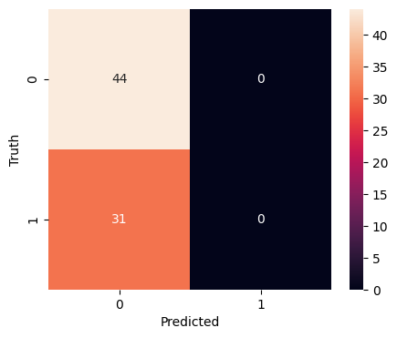

```python
# 7. Prediction and Confusion matrix

y_predicted = classifier.predict(x_test)

y_predicted_labels = [np.argmax(i) for i in y_predicted]

cm = tf.math.confusion_matrix(labels = y_test,predictions = y_predicted_labels)

plt.figure(figsize = (5,4))
sns.heatmap(cm,annot = True,fmt = 'd')
plt.xlabel("Predicted")
plt.ylabel("Truth")
```

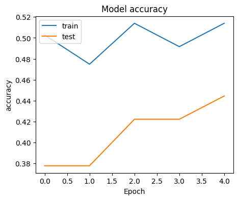

```python
# 8. Plottings

plt.figure(figsize = (5,4))
plt.plot(model_history.history['accuracy'])
plt.plot(model_history.history['val_accuracy'])
plt.title('Model accuracy')
plt.xlabel('Epoch')
plt.ylabel('accuracy')
plt.legend(['train','test'],loc="upper left")
plt.show()
```

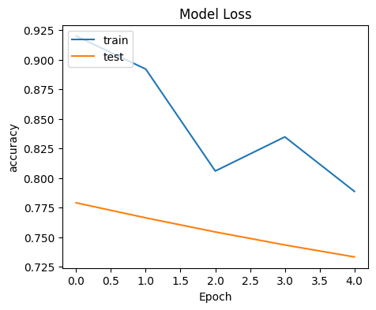

```python
plt.figure(figsize = (5,4))
plt.plot(model_history.history['loss'])
plt.plot(model_history.history['val_loss'])
plt.title('Model Loss')
plt.xlabel('Epoch')
plt.ylabel('accuracy')
plt.legend(['train','test'],loc="upper left")
plt.show()
```

# ANN Images

## Building a deep learning model that can accurately recognize handwritten digits based on the MNIST dataset

```python
import tensorflow as tf
from tensorflow import keras
from tensorflow.keras.datasets import mnist
import matplotlib.pyplot as plt
import seaborn as sns
import numpy as np
%matplotlib inline
```

```python
# Loading the MNIST dataset, which contains handwritten digits, and splits it into training and testing sets.
(X_train, y_train) , (X_test, y_test) = mnist.load_data()
```

```
Downloading data from https://storage.googleapis.com/tensorflow/tf-keras-datasets/mnist.npz
11490434/11490434 ━━━━━━━━━━━━━━━━━━━━ 0s 0us/step
```

```
60000
10000
(28, 28)
Label: 9
```

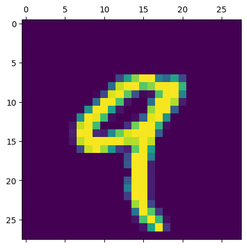

```python
# Exploring Dataset

#1. Checking the size of dataset
print(len(X_train))
print(len(X_test))

#2. Shape of first image
print(X_train[0].shape)

# 3. Label and Image of 5th image
plt.matshow(X_train[4])
print("Label:", y_train[4])
```

```python
# Data preprocessing

# Normalizing the pixel values of the images to be between 0 and 1.
X_train=X_train/255
X_test=X_test/255
```

```python
# Using Flatten layer so that we don't have to call .reshape on input dataset
from keras.models import Sequential
from keras.layers import Flatten,Dense
model = Sequential()
model.add(Flatten(input_shape=(28, 28)))
model.add(Dense(100, activation='relu'))
model.add(Dense(10, activation='softmax'))

model.compile(optimizer='adam', loss='sparse_categorical_crossentropy', metrics=['accuracy'])

model.fit(X_train, y_train, epochs=10)
```

```
1875/1875 ━━━━━━━━━━━━━━━━━━━━ 4s 2ms/step - accuracy: 0.8756 - loss: 0.4509
1875/1875 ━━━━━━━━━━━━━━━━━━━━ 3s 2ms/step - accuracy: 0.9620 - loss: 0.1291
1875/1875 ━━━━━━━━━━━━━━━━━━━━ 6s 2ms/step - accuracy: 0.9746 - loss: 0.0849
1875/1875 ━━━━━━━━━━━━━━━━━━━━ 3s 1ms/step - accuracy: 0.9811 - loss: 0.0644
1875/1875 ━━━━━━━━━━━━━━━━━━━━ 3s 2ms/step - accuracy: 0.9853 - loss: 0.0481
1875/1875 ━━━━━━━━━━━━━━━━━━━━ 6s 2ms/step - accuracy: 0.9886 - loss: 0.0378
1875/1875 ━━━━━━━━━━━━━━━━━━━━ 5s 3ms/step - accuracy: 0.9896 - loss: 0.0328
1875/1875 ━━━━━━━━━━━━━━━━━━━━ 8s 2ms/step - accuracy: 0.9917 - loss: 0.0261
1875/1875 ━━━━━━━━━━━━━━━━━━━━ 3s 2ms/step - accuracy: 0.9938 - loss: 0.0206
1875/1875 ━━━━━━━━━━━━━━━━━━━━ 5s 2ms/step - accuracy: 0.9946 - loss: 0.0173
```

```
<keras.src.callbacks.history.History at 0x7ec76c3e61d0>
```

```python
model.evaluate(X_test, y_test)
```

```
313/313 ━━━━━━━━━━━━━━━━━━━━ 1s 3ms/step - accuracy: 0.9726 - loss: 0.0975
```

```
[0.08356696367263794, 0.9768000245094299]
```

[output not shown]

```
313/313 ━━━━━━━━━━━━━━━━━━━━ 1s 2ms/step
```

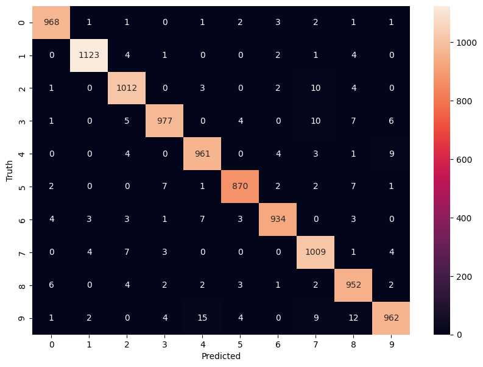

```python
# Evaluating and Visualizing Model Performance
y_predicted = model.predict(X_test)
np.argmax(y_predicted[0])
y_predicted_labels = [np.argmax(i) for i in y_predicted]

cm = tf.math.confusion_matrix(labels=y_test, predictions=y_predicted_labels)

plt.figure(figsize=(10,7))
sns.heatmap(cm, annot=True, fmt='d')
plt.xlabel('Predicted')
plt.ylabel('Truth')
```

# Module 2 - CNN

## Implementing a Convolutional Neural Network (CNN) to classify images of brain tumors into four distinct categories

## BrainTumour

```python
!unzip -u "/content/BrainTumour.zip" -d "/content/BrainTumour"
```

```
unzip:  cannot find or open /content/BrainTumour.zip, /content/BrainTumour.zip.zip or /content/BrainTumour.zip.ZIP.
```

```python
import tensorflow as tf
from tensorflow import keras

from tensorflow.keras.preprocessing.image import ImageDataGenerator
from tensorflow.keras.models import Sequential
from tensorflow.keras.layers import Conv2D,MaxPool2D,Dense,Dropout,Flatten
from tensorflow.keras.regularizers import l2
from tensorflow.keras.optimizers import Adam, Adagrad
from tensorflow.keras.metrics import categorical_crossentropy
from tensorflow.keras.callbacks import EarlyStopping

from sklearn.metrics import confusion_matrix

import numpy as np
import pandas as pd
import matplotlib.pyplot as plt
import seaborn as sns
```

```python
# 1. Importing

train_path = '/content/drive/MyDrive/BrainTumour/Training'
test_path = '/content/drive/MyDrive/BrainTumour/Testing'
train_datagen = ImageDataGenerator(validation_split = 0.2,rescale = 1./255)
test_datagen = ImageDataGenerator(rescale = 1./255)
```

```python
# 2. train validation test batches

train_batches = train_datagen.flow_from_directory(
    train_path,target_size = (64,64),
    batch_size = 32,
    subset = 'training',
    class_mode = 'categorical'
)

validation_batches = train_datagen.flow_from_directory(
    train_path,target_size = (64,64),
    batch_size = 32,
    subset = 'validation',
    class_mode = 'categorical'
)

test_batches = test_datagen.flow_from_directory(
    test_path,target_size = (64,64),
    batch_size = 32,
    subset = 'training',
    class_mode = 'categorical'
)
```

```
Found 2297 images belonging to 4 classes.
Found 573 images belonging to 4 classes.
Found 394 images belonging to 4 classes.
```

```python
# 3. Model

model = Sequential()
model.add(Conv2D(32,3,activation = 'relu',input_shape = (64,64,3)))
model.add(Dropout(0.25))
model.add(Conv2D(64,3,activation='relu',kernel_regularizer=l2(0.01)))
model.add(MaxPool2D())
model.add(Flatten())
# Hidden Layer
# model -1
model.add(Dense(128,activation = 'relu'))
model.add(Dropout(0.25))
# model-2
model.add(Dense(64,activation = 'relu'))
model.add(Dropout(0.25))
# model - 3
model.add(Dense(32,activation = 'relu'))
model.add(Dropout(0.25))
# output layer
model.add(Dense(4,activation = 'softmax'))
```

```python
# 4. Two optimizers (Run whole code with another optimizer)

model.compile(optimizer='adam', loss='categorical_crossentropy', metrics=['accuracy'])
```

```python
# 5. fit

early_stopping = EarlyStopping(monitor='val_loss', min_delta=0.001, patience=5, verbose=0, mode='auto')

history = model.fit(x=train_batches, validation_data=validation_batches, epochs=10, verbose=1, callbacks=[early_stopping])
```

```
72/72 ━━━━━━━━━━━━━━━━━━━━ 808s 10s/step - accuracy: 0.3467 - loss: 1.8245 - val_accuracy: 0.4206 - val_loss: 1.4145
72/72 ━━━━━━━━━━━━━━━━━━━━ 12s 157ms/step - accuracy: 0.5367 - loss: 1.2050 - val_accuracy: 0.4311 - val_loss: 1.2383
72/72 ━━━━━━━━━━━━━━━━━━━━ 12s 157ms/step - accuracy: 0.6636 - loss: 0.8612 - val_accuracy: 0.4869 - val_loss: 1.2506
72/72 ━━━━━━━━━━━━━━━━━━━━ 20s 151ms/step - accuracy: 0.7309 - loss: 0.7505 - val_accuracy: 0.5969 - val_loss: 1.1680
72/72 ━━━━━━━━━━━━━━━━━━━━ 12s 153ms/step - accuracy: 0.7583 - loss: 0.6144 - val_accuracy: 0.5654 - val_loss: 1.1919
72/72 ━━━━━━━━━━━━━━━━━━━━ 21s 156ms/step - accuracy: 0.8128 - loss: 0.5177 - val_accuracy: 0.5637 - val_loss: 1.1800
72/72 ━━━━━━━━━━━━━━━━━━━━ 12s 160ms/step - accuracy: 0.8489 - loss: 0.4061 - val_accuracy: 0.5707 - val_loss: 1.2865
72/72 ━━━━━━━━━━━━━━━━━━━━ 20s 151ms/step - accuracy: 0.9017 - loss: 0.3188 - val_accuracy: 0.5620 - val_loss: 1.3848
72/72 ━━━━━━━━━━━━━━━━━━━━ 12s 155ms/step - accuracy: 0.8880 - loss: 0.3302 - val_accuracy: 0.6021 - val_loss: 1.5668
```

```python
# 6. Evalaution

#history.history.keys()

accuracy = history.history['accuracy'][-1] * 100
val_accuracy = history.history['val_accuracy'][-1] * 100

print(f'Training accuracy: {round(accuracy, 2)}%')
print(f'Validation accuracy: {round(val_accuracy, 2)}%')
```

```
Training accuracy: 89.81%
Validation accuracy: 60.21%
```

```
13/13 ━━━━━━━━━━━━━━━━━━━━ 98s 8s/step
```

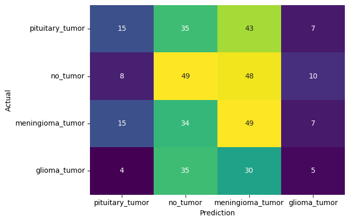

```python
# 7. Prediction and confusion matrix

predictions = model.predict(test_batches)

predictions = np.round(predictions)

cm = confusion_matrix(y_true=test_batches.classes,y_pred=np.argmax(predictions,axis=1))
ax = sns.heatmap(cm, annot=True, xticklabels=["pituitary_tumor",'no_tumor',"meningioma_tumor","glioma_tumor"],
                 yticklabels=["pituitary_tumor",'no_tumor',"meningioma_tumor","glioma_tumor"],cbar=False,cmap='viridis')
ax.set_xlabel('Prediction')
ax.set_ylabel('Actual')
plt.show()
```

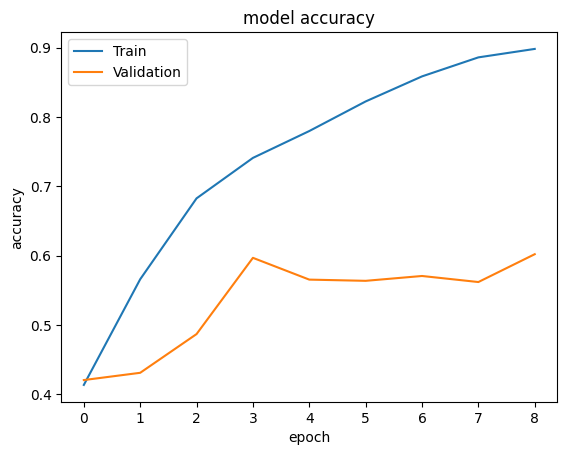

```python
# 8. Summarize history for accuracy

plt.plot(history.history['accuracy'])
plt.plot(history.history['val_accuracy'])
plt.title('model accuracy')
plt.ylabel('accuracy')
plt.xlabel('epoch')
plt.legend(['Train', 'Validation'], loc='upper left')
plt.show()
```

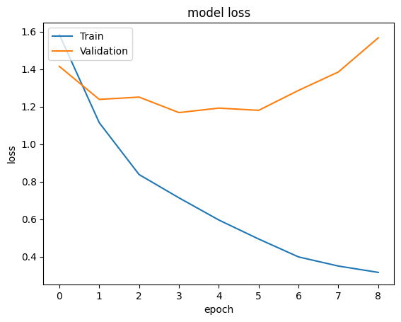

```python
plt.plot(history.history['loss'])
plt.plot(history.history['val_loss'])
plt.title('model loss')
plt.ylabel('loss')
plt.xlabel('epoch')
plt.legend(['Train', 'Validation'], loc='upper left')
plt.show()
```

# Module 3 - RNN

## Classification of names as either male or female using a character-level recurrent neural network (RNN)

## Gender Classification

```python
import numpy as np

from sklearn.model_selection import train_test_split

from tensorflow.keras.preprocessing.text import Tokenizer
from tensorflow.keras.preprocessing.sequence import pad_sequences
from tensorflow.keras.models import Sequential
from tensorflow.keras.layers import SimpleRNN, Dense, Embedding
```

```python
# Dataset
names = ['John', 'Jane', 'Alice', 'Bob', 'Michael', 'Mary', 'David', 'Sarah', 'James', 'Emily',
         'William', 'Emma', 'Matthew', 'Olivia', 'Daniel', 'Sophia', 'Christopher', 'Isabella', 'Andrew', 'Ava']
genders = ['male', 'female', 'female', 'male', 'male', 'female', 'male', 'female', 'male', 'female',
           'male', 'female', 'male', 'female', 'male', 'female', 'male', 'female', 'male', 'female']
```

```python
# Data Preprocessing

# 1. Convert names to numerical representation
tokenizer = Tokenizer(char_level=True)
tokenizer.fit_on_texts(names)
print("Vocabulary:", tokenizer.word_index)

X = tokenizer.texts_to_sequences(names)
print(X)

# 2. Pad sequences to a fixed length
max_length = max(len(seq) for seq in X)
X = pad_sequences(X, maxlen=max_length, padding='post')
print(X)

X = np.array(X)    # Convert to numpy array

# 3. One-hot encode genders
y = np.array([1 if gender == 'male' else 0 for gender in genders])

# 4. Split dataset into training and testing sets
X_train, X_test, y_train, y_test = train_test_split(X, y, test_size=0.2, random_state=42)
print(len(tokenizer.word_index))
print(X.shape[1])
```

```
Vocabulary: {'a': 1, 'i': 2, 'e': 3, 'l': 4, 'm': 5, 'h': 6, 'o': 7, 'r': 8, 's': 9, 'n': 10, 'd': 11, 'j': 12, 'c': 13, 'b': 14, 'v': 15, 'w': 16, 't': 17, 'y': 18, 'p': 19}
[[12, 7, 6, 10], [12, 1, 10, 3], [1, 4, 2, 13, 3], [14, 7, 14], [5, 2, 13, 6, 1, 3, 4], [5, 1, 8, 18], [11, 1, 15, 2, 11], [9, 1, 8, 1, 6], [12, 1, 5, 3, 9], [3, 5, 2, 4, 18], [16, 2, 4, 4, 2, 1, 5], [3, 5, 5, 1], [5, 1, 17, 17, 6, 3, 16], [7, 4, 2, 15, 2, 1], [11, 1, 10, 2, 3, 4], [9, 7, 19, 6, 2, …
[[12  7  6 10  0  0  0  0  0  0  0]
 [12  1 10  3  0  0  0  0  0  0  0]
 [ 1  4  2 13  3  0  0  0  0  0  0]
 [14  7 14  0  0  0  0  0  0  0  0]
 [ 5  2 13  6  1  3  4  0  0  0  0]
 [ 5  1  8 18  0  0  0  0  0  0  0]
 [11  1 15  2 11  0  0  0  0  0  0]
 [ 9  1  8  1  6  0  0  0  0  0  0]
 [12  1  5  3  9  0  0  0  0  0  0]
 [ 3  5  2  4 18  0  0  0  0  0  0]
 [16  2  4  4  2  1  5  0  0  0  0]
 [ 3  5  5  1  0  0  0  0  0  0  0]
 [ 5  1 17 17  6  3 16  0  0  0  0]
 [ 7  4  2 15  2  1  0  0  0  0  0]
 [11  1 10  2  3  4  0  0  0  0  0]
 [ 9  7 19  6  2  1  0  0  0  0  0]
 [13  6  8  2  9 17  7 19  6  3  8]
 [ 2  9  1 14  3  4  4  1  0  0  0]
 [ 1 10 11  8  3 16  0  0  0  0  0]
 [ 1 15  1  0  0  0  0  0  0  0  0]]
19
11
```

```python
# Simple RNN model
model = Sequential()
model.add(Embedding(input_dim=len(tokenizer.word_index) + 1, output_dim=10, input_length=X.shape[1]))
model.add(SimpleRNN(10))
model.add(Dense(1, activation='sigmoid'))

model.compile(optimizer='adam', loss='binary_crossentropy', metrics=['accuracy'])

model.fit(X_train, y_train, epochs=10, batch_size=1, verbose=1)
```

```
16/16 ━━━━━━━━━━━━━━━━━━━━ 3s 3ms/step - accuracy: 0.6526 - loss: 0.6732
16/16 ━━━━━━━━━━━━━━━━━━━━ 0s 3ms/step - accuracy: 0.5441 - loss: 0.6660
16/16 ━━━━━━━━━━━━━━━━━━━━ 0s 3ms/step - accuracy: 0.9269 - loss: 0.5826
16/16 ━━━━━━━━━━━━━━━━━━━━ 0s 3ms/step - accuracy: 0.8733 - loss: 0.5417
16/16 ━━━━━━━━━━━━━━━━━━━━ 0s 3ms/step - accuracy: 0.9751 - loss: 0.4394
16/16 ━━━━━━━━━━━━━━━━━━━━ 0s 3ms/step - accuracy: 0.9053 - loss: 0.3288
16/16 ━━━━━━━━━━━━━━━━━━━━ 0s 4ms/step - accuracy: 1.0000 - loss: 0.2234
16/16 ━━━━━━━━━━━━━━━━━━━━ 0s 3ms/step - accuracy: 1.0000 - loss: 0.1863
16/16 ━━━━━━━━━━━━━━━━━━━━ 0s 3ms/step - accuracy: 1.0000 - loss: 0.1059
16/16 ━━━━━━━━━━━━━━━━━━━━ 0s 6ms/step - accuracy: 1.0000 - loss: 0.0974
```

```
<keras.src.callbacks.history.History at 0x7ec76c34d690>
```

```python
# Evaluation and validation
loss, accuracy = model.evaluate(X_test, y_test, verbose=0)
print(f'Test Accuracy: {accuracy * 100:.2f}%')
```

```
Test Accuracy: 25.00%
```

```python
# Prediction and Testing

# Define a function to predict gender for a given name
def predict_gender(name):
    name_seq = tokenizer.texts_to_sequences([name])   # Convert names to numerical representation

    max_length = max(len(name_seq) for name_seq in X)     # Pad sequences to a fixed length
    name_seq = pad_sequences(name_seq, maxlen=max_length, padding='post')

    name_seq = np.array(name_seq)     # Convert to numpy array

    prediction = model.predict(name_seq)[0][0]       # Make the prediction

    gender = 'male' if prediction >= 0.5 else 'female'       # Convert prediction to gender label

    return gender

# Testing with a random name
random_name = 'Emma'
predicted_gender = predict_gender(random_name)
print(f"The predicted gender for the name '{random_name}' is: {predicted_gender}")
```

```
1/1 ━━━━━━━━━━━━━━━━━━━━ 0s 265ms/step
The predicted gender for the name 'Emma' is: female
```